# STAT 5410 Final Project

Analysis of Area Codes

Author

Alex Schwarz

# Environment Setup

Below is a list of the libraries used during this project to help with the analysis.

```r
library(tidyverse) # ggplot2, dplyr, tidyr, readr, purrr, tibble, stringr, forcats, lubridate
library(readxl) # Used reading in Excel data
library(sf) # Used for reading the simple features data
library(janitor) # clean_names()
library(broom) # tidy()
library(tidymodels) # recipes / workflows / parsnip
library(glmnet) # classification regression
library(kknn) # used for K-Nearest Neighbors
library(rsample) # used for validation testing
library(knitr) # used for displaying tables

select <- dplyr::select
theme_set(theme_bw())
```

# Data Information

Data Frame Name

Description

sf_data

Simple Features shapes for the maps of counties in the U.S.

- `AREA`: the area of the region in terms of thousands of square kilometers.
- `STATE`: providing the state FIPS code.
- `COUNTY`: providing the county FIPS code.
- `NAME`: Providing the name of the county
- `geometry` containing the simple features object of the area.

splits_overlays

Original American area codes.

- `Code`: the zip code
- `year`: year the code was first used
- `original`: logical variable if it was or wasn’t the original area code
- `territory`: area covered by the code today (state (county(ies)))

cities_area_codes_final

- `area_code`: the zip code
- `city`: city/town of the state it’s located
- `state_or_province`: state or province
- `country`: country it pertains to

censusdata

- `state_name`: state name
- `state_fips_code`: state fips code associated
- `county_fips_code`: county fips code associated
- `county_name`: county name
- `population_1950`: population of a county in 1950
- `residence_telephones_1945`: count of telephones in 1945
- `population_under5_1950`: population of people under 5 in 1950
- `population_over65_1950`: population of people over 65 in 1950
- `births`: number of births
- `black_pop`: population of black individuals

merged_counties_1950

- `county_name`: county name
- `state_fips`: state fips code
- `state_name`: state name
- `old_county_fips`: original county fips code
- `new_county_fips`: new county fips code that it merged into

new_counties_1950

- `state`: state name
- `state_fips`: state fips code
- `new_county_name`: new county name it became
- `new_county_fips`: new county fips code assigned
- `old_county_name`: old county name changed from
- `old_county_fips`: original county fips code

# Data Loading

```r
# Show all files in our data folder
list.files("data")

# Read main files
cities_area_codes_final <- read.csv("data/cities_area_codes_final.csv")
censusdata <- read.csv("data/county_census_info.csv")
merged_counties_1950 <- read.csv("data/merged_counties_since_1950.csv")
new_counties_1950 <- read.csv("data/new_counties_since_1950.csv")
```

```r
# Set sheet names
sheets <- excel_sheets("data/splits_overlays.xlsx")

# Read splits_overlays file for each tab
splits_overlays <- tibble(path = "data/splits_overlays.xlsx",
                          zips = sheets)

splits_overlays <- splits_overlays |>
  rowwise() |>
  mutate(splits_overlays = list(read_xlsx(path,
                                          sheet = zips)))

# Unnest each page to create one df
splits_overlays <- splits_overlays |>
  select(original_area_code = zips,
         splits_overlays) |>
  unnest(splits_overlays)
```

```r
# Load sf data
sf_data <- st_read("data/co99_d00_shp/co99_d00.shp")

sf_data <- sf_data |>
  st_set_crs(4269)
```

Additional data set pulled from https://transition.fcc.gov/oet/info/maps/census/fips/fips.txt to make it easier to reference combining data

```r
# Load state FIPS codes
state_fips <- read.csv("data/state_fips.csv")
```

# Data Cleaning

## state_fips

```r
# Change state name to title case
state_fips <- state_fips |>
  mutate(state_name = str_to_title(state_name)) |>
  glimpse()

# Commented out after use
# Check what Hawaii and Alaska are to remove
# state_fips |>
#   filter(state_name %in% c("Hawaii",
#                            "Alaska"))
```

## sf_data

```r
# Update field data types
# Rename fields to be consistent
# Filter out Alaska and Hawaii
sf_data <- sf_data |>
  clean_names() |>
  mutate(state = as.integer(state),
         county = as.integer(county),
         lsad = as.integer(lsad)) |>
  rename(county_fips = county,
         state_fips = state,
         county_name = name) |>
  # Filter out Hawaii and Alaska
  filter(!state_fips %in% c(2,
                            15),
         lsad_trans == "County")

# Preview
sf_data |>
  glimpse()
```

## splits_overlays

```r
# Update correct field types
# Remove unnecessary rows
splits_overlays <- splits_overlays |>
  mutate(original_area_code = as.integer(original_area_code),
         new_area_code = as.integer(code),
         year = as.integer(year)) |>
  select(-code, -territory, -year)

splits_overlays |>
  glimpse()
```

## cities_area_codes_final

```r
# Filter for area codes only in the US or USA
# Filter out Alaska and Hawaii
cities_area_codes_final <- cities_area_codes_final |>
  filter(country %in% c("US",
                        "USA")) |>
  rename(state_name = state_or_province) |>
  filter(!state_name %in% c("Alaska",
                            "Hawaii"))

cities_area_codes_final |>
  glimpse()
```

## censusdata

```r
# Fix string casing
# Fix field names
# Filter out Alaska and Hawaii
censusdata <- censusdata |>
  mutate(state_name = str_to_title(state_name),
         county_name = str_to_title(county_name)) |>
  rename(state_fips = state_fips_code,
         county_fips = county_fips_code) |>
  filter(!state_name %in% c("Alaska",
                            "Hawaii"))

censusdata |>
  glimpse()
```

## merged_counties_1950

```r
# Fix field cases
# Filter out Alaska and Hawaii
merged_counties_1950 <- merged_counties_1950 |>
  mutate(county_name = str_to_title(county_name),
         state_name = str_to_title(state_name)) |>
  filter(!state_name %in% c("Alaska",
                            "Hawaii")) |>
  glimpse()
```

## new_counties_1950

```r
# Fix field name
new_counties_1950 <- new_counties_1950 |>
  rename(state_name = state)

new_counties_1950 |>
  glimpse()
```

# COMPONENT 1

Create map visualizations of the complete areas corresponding to the original area codes.

Visualizing the entire USA leads to a graphic that is much too crowded with far too many area codes. As such, I request that you instead include individual graphics for six different states of your choice. The graphic should show a map of the state, with regions colored according to their area.

At least four of the states included must be from the list of multi-code states:

- California
- New York
- Texas
- Pennsylvania
- Ohio
- Illinois
- Minnesota
- Michigan
- Missouri
- Kansas
- Indiana
- Iowa
- Massachusetts
- Wisconsin

For your reference, [this website](https://lincmad.com/map1947.html) shows someone’s hand-drawn version of the approximate numbering plan for the entire US, using text instead of colors. [This technical report](https://underunderstood.com/podcast/wp-content/uploads/2021/03/NPA-History-and-Map.pdf) from Bell Labs contains a similar hand-drawn map (Map 3) on the final page.

Note 1: Our area code by city dataset does not contain cities in every US county, so there will be some counties where the true original area code assignment data is missing and you’ll need to impute it with a model-based guess. As such, I do not expect your map to perfectly align with those shown above, particular for low-population counties. These low population counties are unlikely to impact the results anyway.

Note 2: You may notice that your final map for California differs quite a bit from the renderings above. That is because the area code 916 has complete moved areas since it was originally proposed, causing a bunch of weird data issues. So, don’t worry if your California map looks different in the North.

## Data Preparation

### Combine splits_overlays to cities_area_codes_final

```r
# Add splits_overlays to cities_area_codes_final
area_codes_combined <- cities_area_codes_final |>
  left_join(splits_overlays,
            by = join_by(area_code == new_area_code)) |>
    rename(new_area_code = area_code) |>
  glimpse()
```

### Combine sf_data with the combined data

```r
# Convert the combined df to a simple features df
sf_areacodes <- st_as_sf(area_codes_combined,
                         coords = c("longitude", "latitude"),
                         crs = 4269) |>
  glimpse()

# Join sf_data with our new sf_areacodes. This joins based on point geometry within polygon geometry
cities_with_counties <- st_join(sf_areacodes,
                                sf_data)

cities_with_counties <- cities_with_counties |>
  mutate(state_fips = if_else(state_fips == 55 & state_name == "Minnesota",
                               27,
                               state_fips))

# Drop point geometry from our combined data to join polygon data in the next step
cities_with_counties_nogeom <- st_drop_geometry(cities_with_counties) |>
  glimpse()


# Join new data on sf_data preserve polygon data. Note: This will create NA's as sf_data contains more
combined_sf <- sf_data |>
  left_join(cities_with_counties_nogeom) |>
  glimpse()


# Change original_area_code to a factor
combined_sf <- combined_sf |>
  mutate(original_area_code = as.factor(original_area_code))
```

## Visualize Maps - Before Predictions

### California

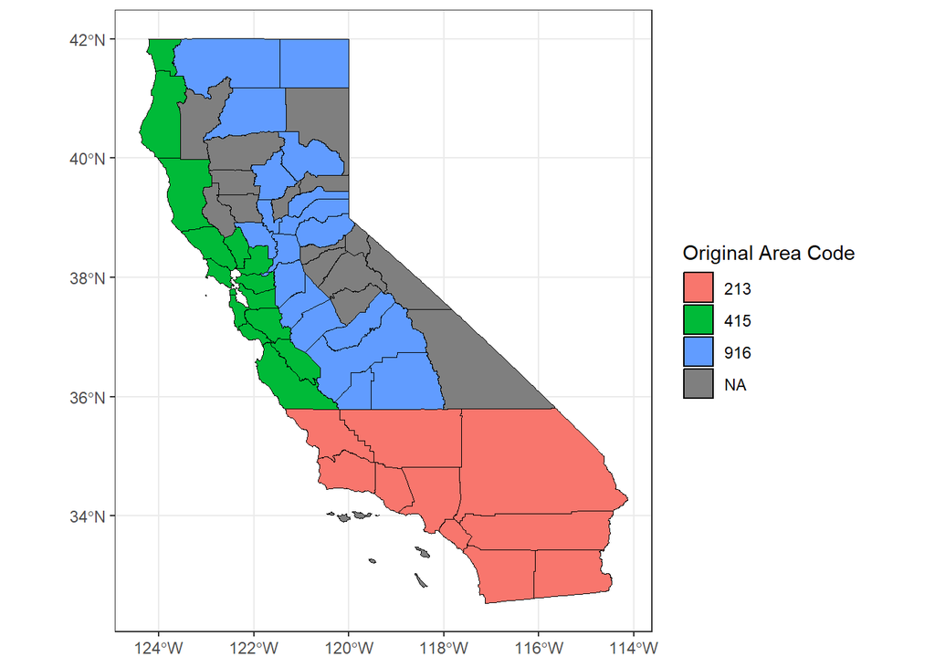

### Connecticut

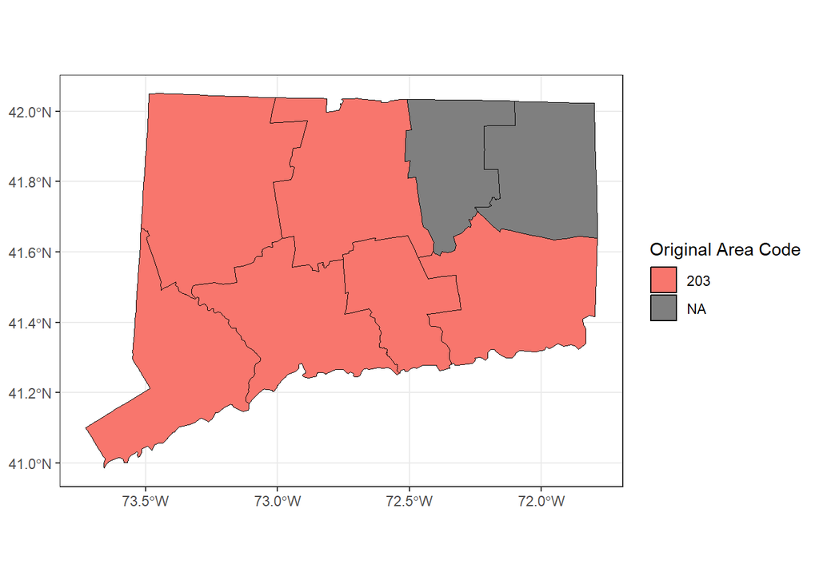

### Massachusetts

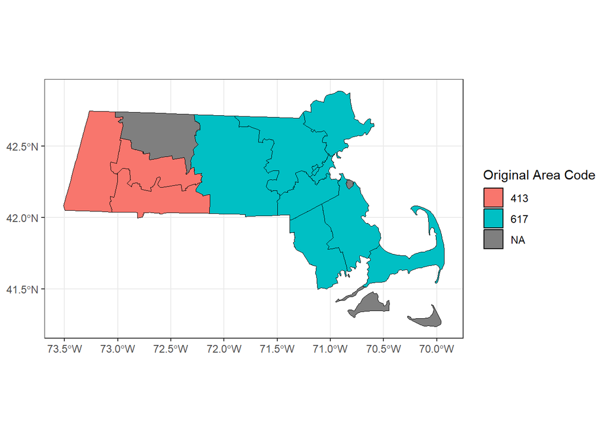

### Minnesota

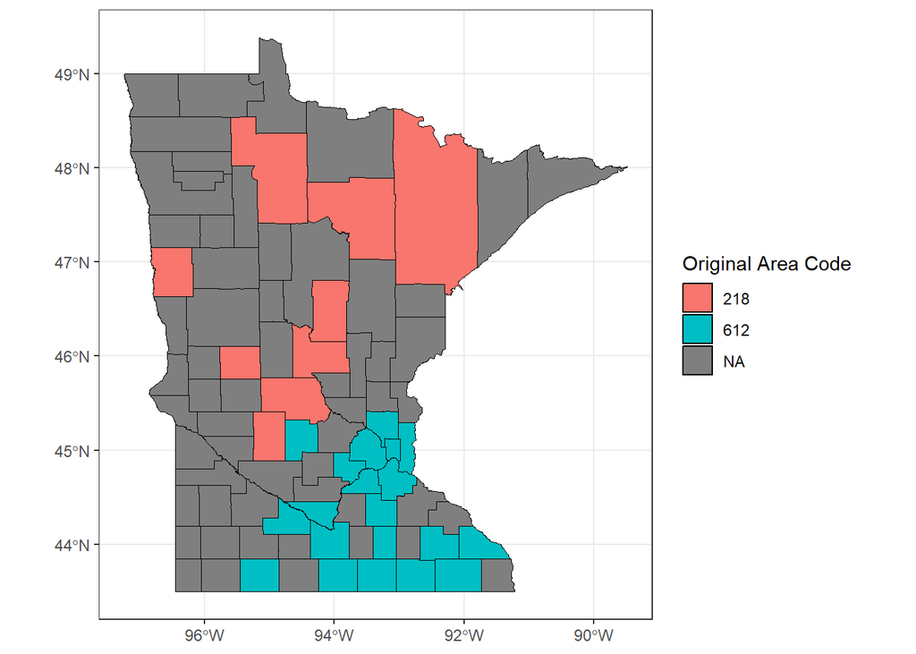

### Washington

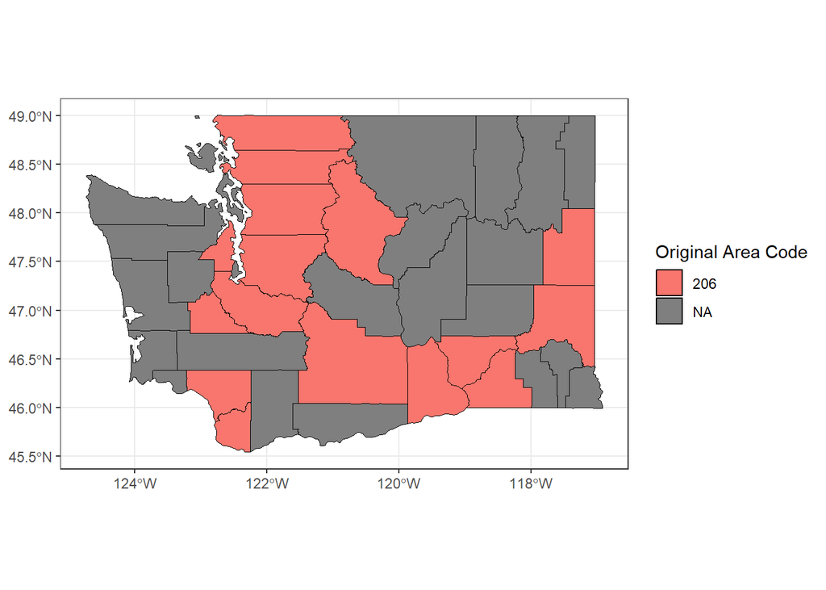

### Wisconsin

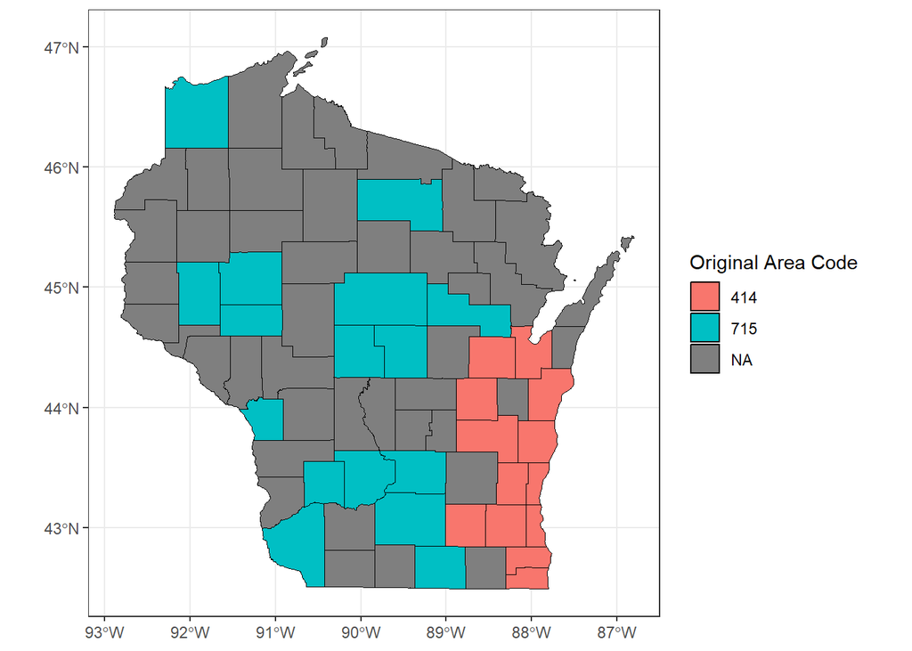

## Impute Predictions

### Create Lat / Long

```r
# Create longitude and latitude from the geometry field
combined_sf <- combined_sf |>
  mutate(centroid = st_centroid(geometry) |>
           st_coordinates(),
         centroid_lat = centroid[,2],
         centroid_long = centroid[,1]) |>
  select(-centroid)
```

### Create training and missing data

```r
# Split into two datasets, original missing and original present
combined_sf_train <- combined_sf |>
  filter(!is.na(original_area_code)) |>
  glimpse()

combined_sf_train |>
  filter(state_fips == 55)

combined_sf_missing <- combined_sf |>
  filter(is.na(original_area_code)) |>
  glimpse()
```

### Set up classification model

```r
# Set up the classification model
classification_knn <- nearest_neighbor(neighbors = 1,
                                       weight_func = "rectangular") |>
  set_engine("kknn") |>
  set_mode("classification")
```

### Fit the model and predict values

```r
# Fit the model
og_codes_fit <- classification_knn |>
  fit(original_area_code ~ centroid_lat + centroid_long + state_fips,
      data = combined_sf_train)

# Predict
og_codes_predict <- og_codes_fit |>
  predict(combined_sf_missing,
          type = "class")
```

### Add predicted values to missing data

```r
# Add the predictions to the missing data
combined_sf_fixed <- combined_sf_missing |>
  mutate(original_area_code = og_codes_predict |>
           pull(.pred_class))
```

### Re-Combine data sets

```r
# Re-combine the data
og_codes_fixed <- combined_sf_train |>
  bind_rows(combined_sf_fixed)
```

## Visualize Maps - After Predictions

### California

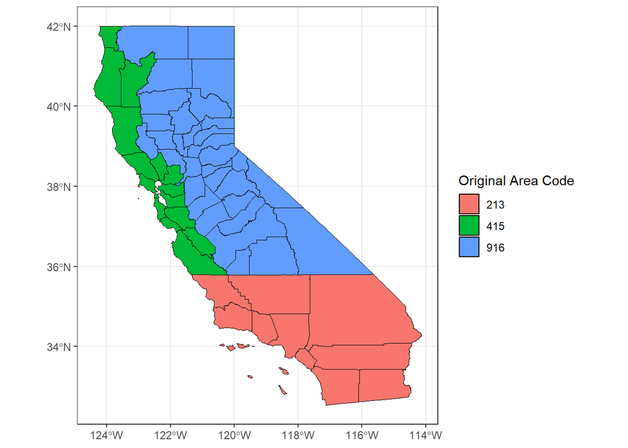

### Connecticut

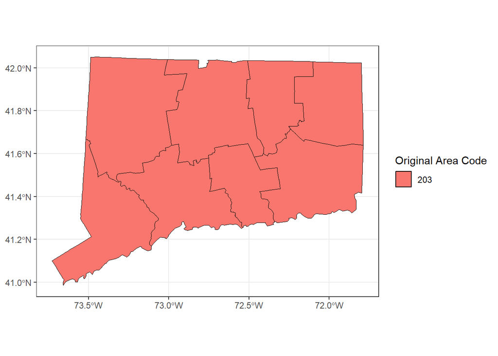

### Massachusetts

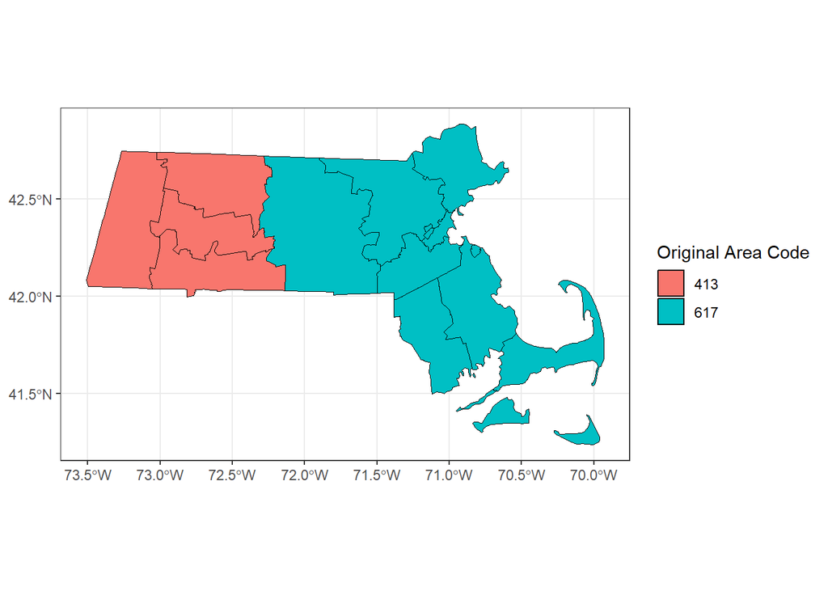

### Minnesota

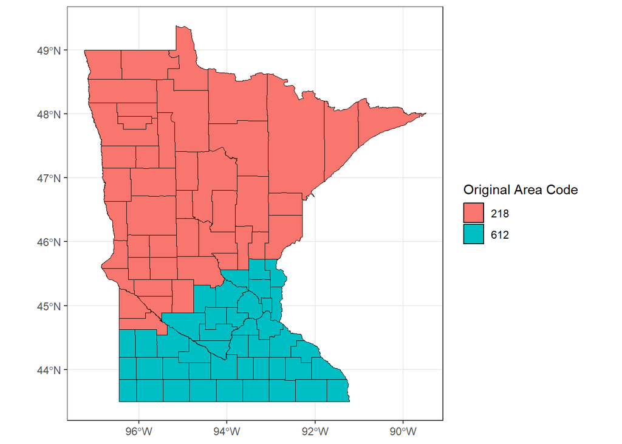

### Washington

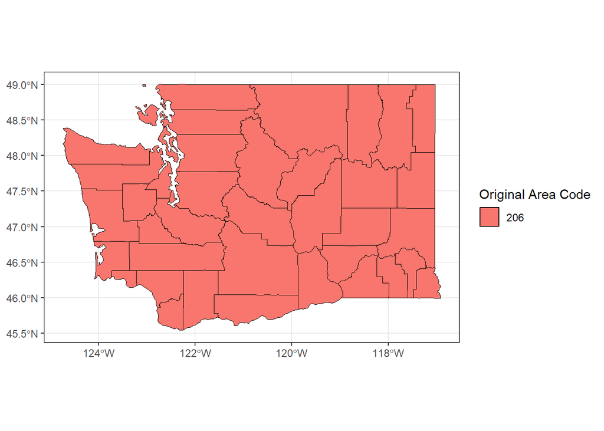

### Wisconsin

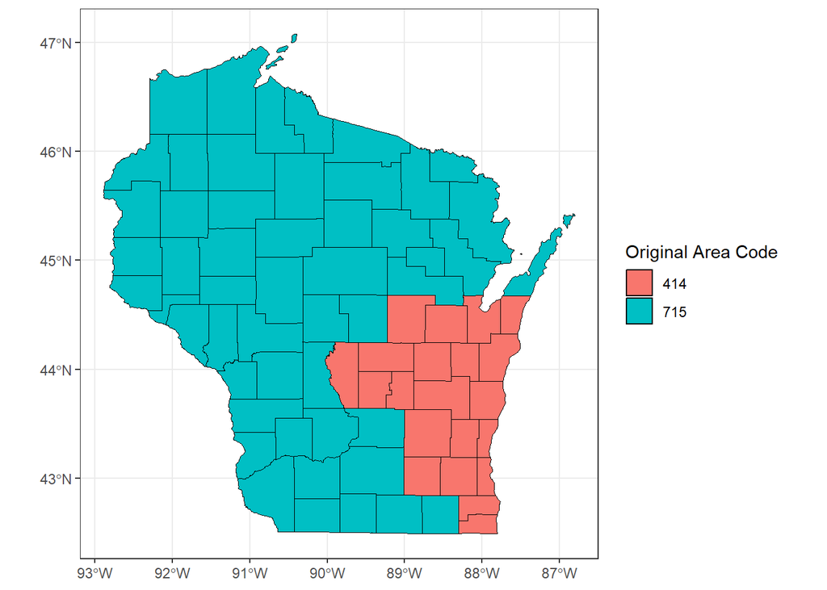

# COMPONENT 2

Conduct an analysis to investigate the question: were higher population areas more likely to be assigned area codes that were faster to dial (required fewer dial pulls) on rotary phones?

Your analysis should include at least one formal hypothesis test with a p-value, as well as at least one graphic illustrating your findings.

Depending on how you approach the problem, it might be worth considering one-code and multiple-code states separately.

## **Research Question:**

Do regions with larger populations tend to have area codes that are faster to dial, as determined by the number of dial pulls required?

For this problem, a “region” is determined by the county. Each county corresponds to a given population size and is assigned an area code used in the dial pull. I will be determining the relationship between population size and the number of dial pulls.

## **Hypothesis:**

*Null Hypothesis*: There is no significant relationship between a region’s population size and the number of dial pulls .

*Alternative Hypothesis:* There is a significant relationship between a region’s population size and the number of dial pulls.

## Data Preparation

### Data Aggregation

```r
# Take the original codes with fixed/imputed areas and add new counties
og_codes_fixed_1 <- og_codes_fixed |>
  left_join(new_counties_1950,
            by = join_by(state_fips == state_fips,
                         county_fips == new_county_fips,
                         county_name == new_county_name)) |>
  mutate(county_fips = if_else(is.na(old_county_fips),
                               county_fips,
                               old_county_fips),
         county_name = if_else(is.na(old_county_fips),
                               county_name,
                               old_county_name),
         state_name = state_name.x) |>
  select(-state_name.x, -state_name.y, -old_county_name, -old_county_fips) |>
           glimpse()

# Take that new one and add merged counties
og_codes_fixed_1 <- og_codes_fixed_1 |>
  bind_rows(merged_counties_1950) |>
  mutate(county_fips = if_else(is.na(county_fips),
                               old_county_fips,
                               county_fips)) |>
  select(-new_county_fips, -old_county_fips) |>
  glimpse()
```

```r
# Add census data for populations and get only the distinct populations
states_population_combined <- og_codes_fixed_1 |>
  select(-city,
         -original,
         -state_name,
         -country) |>
  distinct() |>
  left_join(censusdata,
            by = join_by(state_fips == state_fips,
                         county_fips == county_fips)) |>
  distinct(state_fips, county_fips, population_1950, .keep_all = TRUE) |>
  mutate(county_name = county_name.x) |>
  select(-county_name.x, -county_name.y) |>
  glimpse()

states_population_combined <- states_population_combined |>
  filter(!is.na(lsad_trans)) |>
  glimpse()
```

### Setting up the dial-pull calculations

```r
# Create dial pull number by adding the distances 1-0 (0 = 10 as it's furthest away)
states_population_combined_dials <- states_population_combined |>
  mutate(original_area_code = as.character(original_area_code)) |>
  separate_wider_position(cols = original_area_code,
                          c(digit1 = 1,
                            digit2 = 1,
                            digit3 = 1)) |>
  mutate(original_area_code = str_c(as.character(digit1),
                                    as.character(digit2),
                                    as.character(digit3)),
         digit1 = as.integer(digit1),
         digit2 = as.integer(digit2),
         digit3 = as.integer(digit3)) |>
  mutate(digit1 = if_else(digit1 == 0, 10, digit1),
         digit2 = if_else(digit2 == 0, 10, digit2),
         digit3 = if_else(digit3 == 0, 10, digit3)) |>
  mutate(dial_pulls = as.integer(digit1 + digit2 + digit3))

# Filter out columns that aren't necessary
states_population_combined_dials_filtered <- states_population_combined_dials |>
  select(-area, -perimeter, -co99_d00, -co99_d00_i, - lsad, -lsad_trans) |>
  glimpse()

states_population_combined_dials_filtered |>
  filter(population_1950 >0) |>
  glimpse()
```

## Create the linear regression model and fit the data

```r
# Create a linear model
parsnip_lm <- linear_reg() |>
  set_mode("regression") |>
  set_engine("lm")

parsnip_lm_fit <- parsnip_lm |>
  fit(log(population_1950) ~ dial_pulls,
      data = states_population_combined_dials_filtered |>
              filter(population_1950 > 0,
                     !is.na(original_area_code)))
```

The fit model we receive shows that for every 1 unit of increase in dial pulls, the log decrease in population is -.0575. This is accompanied with a t-statistic of -11.6 and a p-value of 2.62e-30 suggesting that a relatively large negative value for t-statistic means the effect is significantly different from 0 (the null hypothesis). Additionally, the observations we get show that the model is indicative of showing a strong significance as the p-value we receive is much lower than a .05 threshold in which we typically determine the ability to reject the null hypothesis in support of the alternative hypothesis.

```
# A tibble: 2 × 5
  term        estimate std.error statistic  p.value
  <chr>          <dbl>     <dbl>     <dbl>    <dbl>
1 (Intercept)  10.8      0.0788      137.  0
2 dial_pulls   -0.0575   0.00497     -11.6 2.62e-30
```

## View the data

Below, we see a graphical representation, plotting each dial pull with its corresponding log(population). The log-transformed population number was used to normalize the data points to be more visually represented. I’ve fitted a linear regression line to visualize the trend. As number of dial pulls increases, the expected population count goes down.

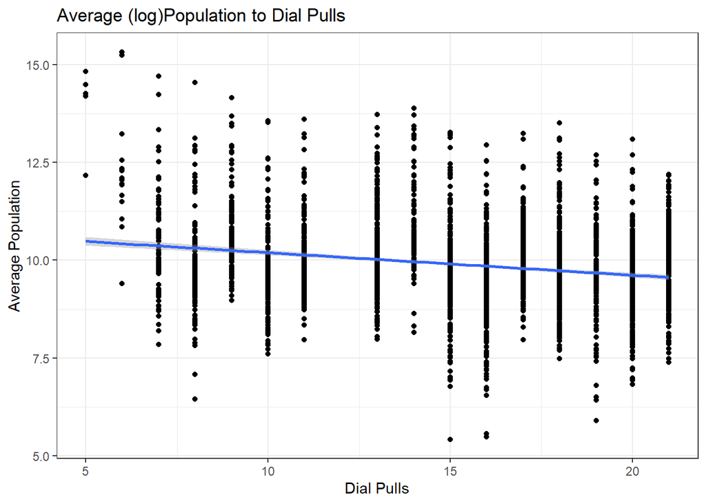

Below, we can see the distribution of log(populations) for each dial pull.

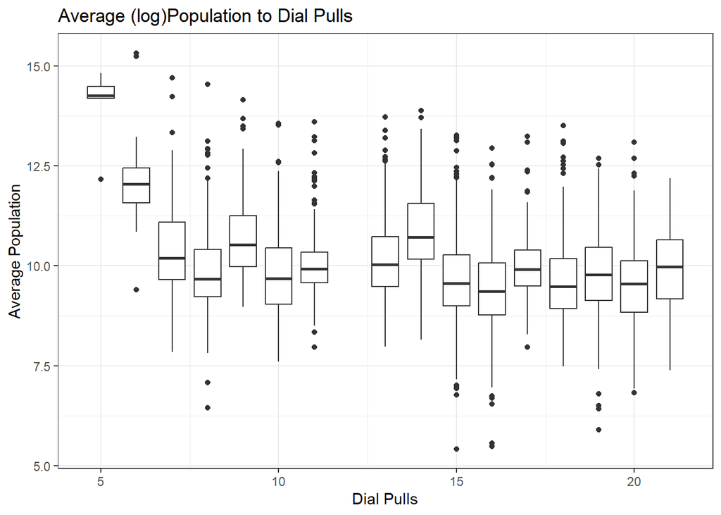

Additionally, when we take the average population for each level, we continue to see a downward trend. As dial pulls increase, we expect to see a decrease in population.

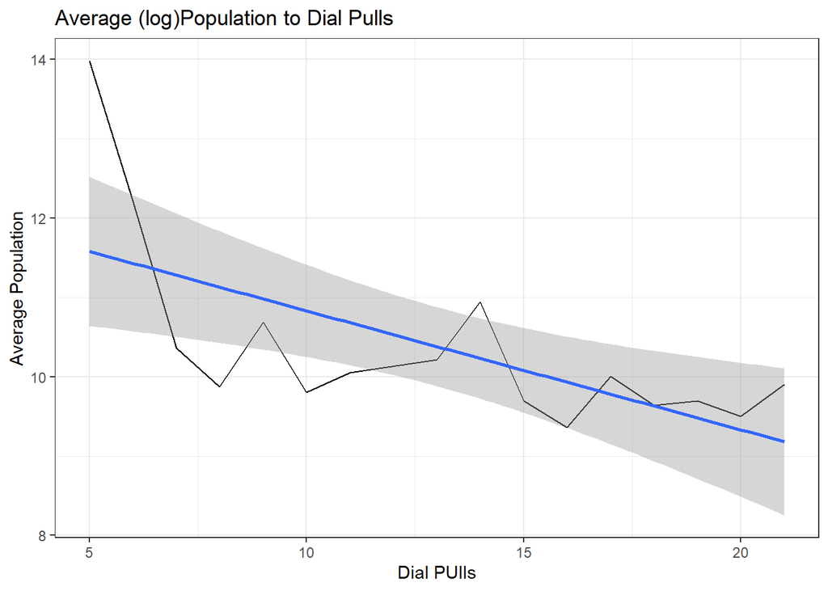

This graph was better showing the relationship of log(population) and shows as the number of dial pulls increases, the population is expected to decrease on average.

Fitting a linear regression model, we see that the statistic is largely negative, along with a very small p-value, showing that the data we observe is congruent with the expectation that higher populations experience lower dial pulls and we have evidence to reject the null hypothesis that there is no significant effect of dial pulls on population in favor of the alternative hypothesis that dial pulls do show a statistical significance.

# COMPONENT 3

Identify regions that you believe were given codes that were unfairly slow to dial given their population. Likewise, identify some regions that you believe were given codes that were unfairly fast to dial.

Provide at least one graphic supporting your claims.

## Predict dial populations based on their dial pulls

```r
parsnip_lm_pred <- predict(parsnip_lm_fit,
                           new_data = states_population_combined_dials_filtered |>
                             filter(population_1950 > 0,
                                    !is.na(original_area_code)))

parsnip_lm_pred |>
  glimpse()
```

## Plot the residuals

The residual values plotted below show the difference of the predicted value from that of the expected value at a specific level. I’ve also included a confidence interval at the mean of the residuals + and - 2 times the standard deviation. Observations outside of these, I’ve marked as being unfairly assigned area codes too slow or too fast.

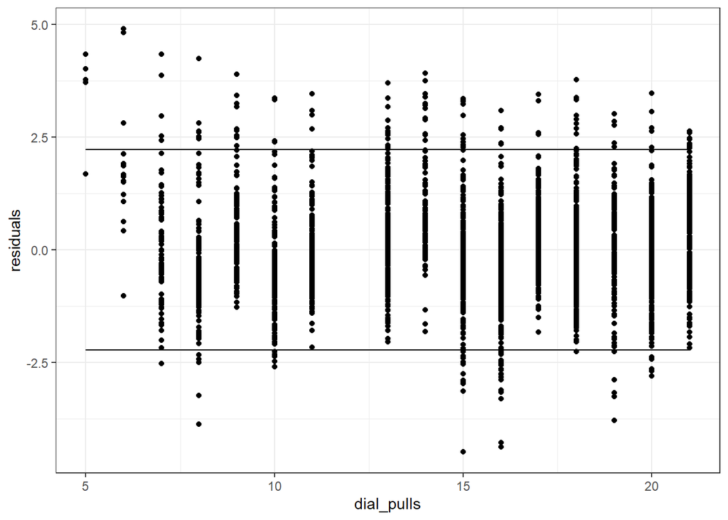

```
# A tibble: 115 × 3
    county_name   state_name     original_area_code
    <chr>         <chr>          <chr>
  1 Spokane       Washington     206
  2 King          Washington     206
  3 Pierce        Washington     206
  4 Multnomah     Oregon         503
  5 Hennepin      Minnesota      612
  6 Ramsey        Minnesota      612
  7 Cumberland    Maine          207
  8 Monroe        New York       716
  9 Kent          Michigan       616
 10 Onondaga      New York       315
 11 Hillsborough  New Hampshire  603
 12 Milwaukee     Wisconsin      414
```

[output cut: 103 more lines]

```
# A tibble: 56 × 3
   county_name   state_name   original_area_code
   <chr>         <chr>        <chr>
 1 Culberson     Texas        915
 2 Edwards       Texas        512
 3 Real          Texas        512
 4 Petroleum     Montana      406
 5 Billings      North Dakota 701
 6 Golden Valley Montana      406
 7 Treasure      Montana      406
 8 Clark         Idaho        208
 9 Camas         Idaho        208
10 Grant         Nebraska     402
11 Hooker        Nebraska     402
12 Wheeler       Nebraska     402
```

[output cut: 44 more lines]

# COMPONENT 4

The year 1947 predated some of the important anti-discrimination laws in the US, including Brown v. Board of Education, the Civil Rights act of 1964, and the voting rights act of 1965.

With regards to area code assignment, can you identify any evidence of anti-black discrimination (in terms of dialing speed) by AT&T against counties with larger African American populations?

You may answer this question graphically, with a formal hypothesis test, or both.

## Graphical representation of Population, removing the count of Black Population

The following is a representation of the population with Black population removed.

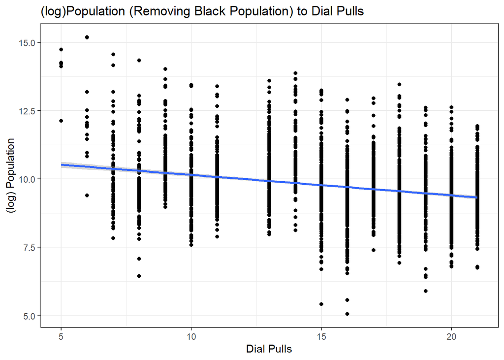

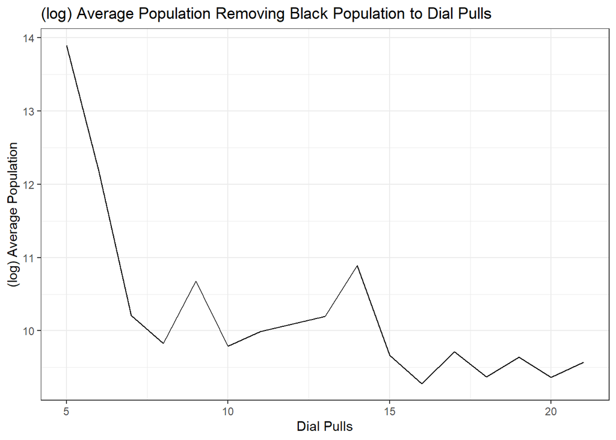

## Fit the model and show the results

```r
parsnip_lm_fit_other <- parsnip_lm |>
  fit(log(other_pop) ~ dial_pulls,
      data = states_population_combined_dials_filtered |>
        mutate(other_pop = population_1950 - black_pop) |>
        filter(other_pop > 0))
```

The following graph shows a negative relationship. As Dial Pulls increases, the population size is expected to decrease. Fitting a linear model to the data shows that for every 1 unit of increase in dial pulls, the log decrease in population is -.0747. This is accompanied with a t-statistic of -14.9 and a p-value of 1.02e-48 suggesting that a relatively large negative value for t-statistic means the effect is significantly different from 0. Additionally, the observations we get show that the model is indicative of showing a strong significance as the p-value we receive is much lower than a .05 threshold in which we typically determine the ability to reject the null hypothesis in support of the alternative hypothesis.

```
# A tibble: 2 × 5
  term        estimate std.error statistic  p.value
  <chr>          <dbl>     <dbl>     <dbl>    <dbl>
1 (Intercept)  10.9      0.0792      138.  0
2 dial_pulls   -0.0747   0.00500     -14.9 1.02e-48
```

## Graphical representation of Black Population

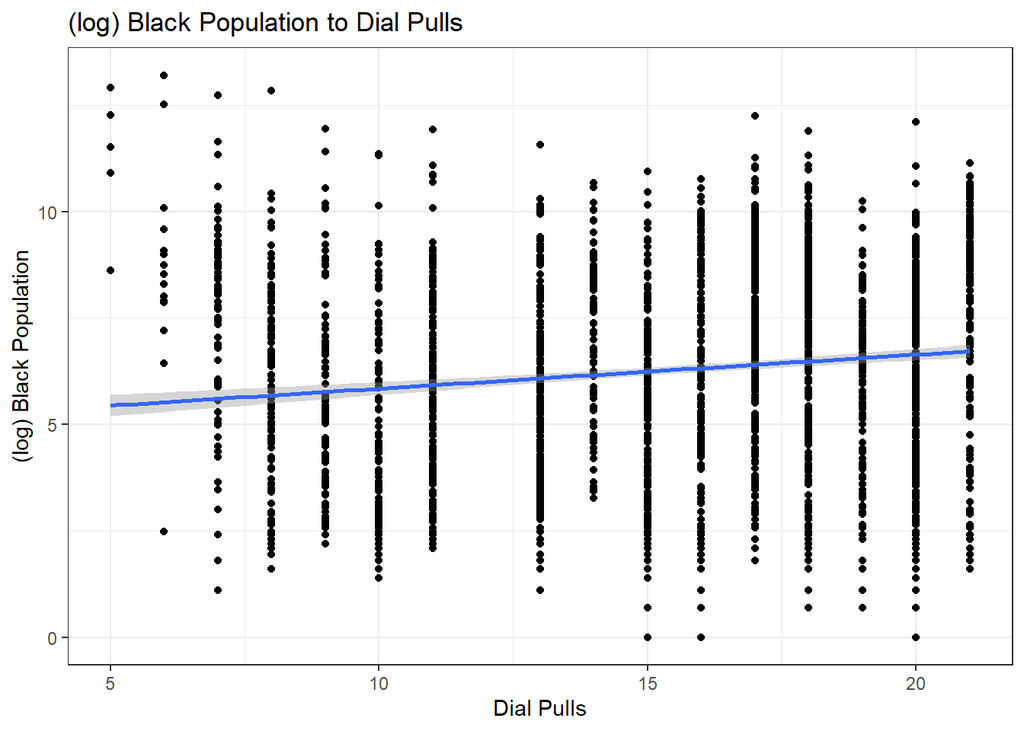

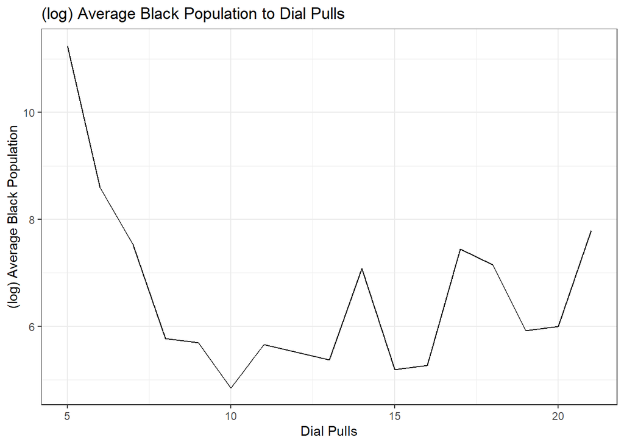

## Fit the model and show the results

Fitting the model against the black population, we see a slight uptick towards the end of the average graph, and fitting a model directly against the population shows a positive relationship of the data. The model fit also suggests a positive relationship as the dial pulls increase we’re expected to see an increase in population on average. This suggests the relationship to be increasing. For every 1 unit of increase in dial pulls, we’re expected to see a .0798 increase in (log) population along with a t-statistic of 6.98 which indicates a relatively strong relationship and that the p-value received is 3.72e-12 and is well below the .05 mark to suggest the difference in means is not 0.

```
# A tibble: 2 × 5
  term        estimate std.error statistic   p.value
  <chr>          <dbl>     <dbl>     <dbl>     <dbl>
1 (Intercept)   5.04      0.182      27.7  5.33e-149
2 dial_pulls    0.0798    0.0114      6.98 3.72e- 12
```

# COMPONENT 5

This component will focus on the task of predicting the current number of area codes assigned to each original area code region, given data concerning that regions which was available in 1950 (e.g. number of births, total region area, latitude/longitude, number dial pulls, etc).

Your write-up should include

- Proposing five different candidate models for the current number of area codes. The models may differ on aspects such as the variables included, algorithm used to fit, link function, etc.
- Devising a criteria on which to judge model performance.
- Determining which model performs best based on these criteria. This usually should involve some sort of cross-validation.
- Interpret the results of this model selection task. What sort of insights does the winning model tell us about the data? Include at least two graphics to support your claims.

## Summarize the data

Here I am summarizing the full data set to understand for each original area code, observable features do we have to predict the end number of area codes. We have 75 original codes to work with.

```r
c5 <- states_population_combined_dials |>
  mutate(original_area_code = as.integer(original_area_code)) |>
  filter(!is.na(original_area_code) &
           !is.na(new_area_code)) |>
  select(where(is.numeric)) |>
  group_by(original_area_code) |>
  summarize(total_area = sum(area),
            total_perimeter = sum(perimeter),
            n_new = n_distinct(new_area_code),
            total_births = sum(births),
            total_population = sum(population_1950),
            total_population_under5 = sum(population_under5_1950),
            total_population_over65 = sum(population_over65_1950),
            total_black_pop = sum(black_pop),
            total_telephones = sum(residence_telephones_1945)) |>
  glimpse()

c5_corrections <- splits_overlays |>
  group_by(original_area_code) |>
  summarize(count = n()) |>
  glimpse()

c5 <- c5 |>
  left_join(c5_corrections) |>
  mutate(n_new = count) |>
  select(-count) |>
  glimpse()
```

## Create Training and Test Data Sets

```r
set.seed(1)

c5_split <- c5 |>
  initial_split(prop = .8)

c5_train <- c5_split |>
  training()

c5_test <- c5_split |>
  testing()
```

## Set Up Model Types

```r
# Create classification models
regression_knn_1 <- nearest_neighbor(neighbors = 1,
                                       weight_func = "rectangular") |>
  set_engine("kknn") |>
  set_mode("regression")

regression_knn_2 <- nearest_neighbor(neighbors = 2,
                                       weight_func = "rectangular") |>
  set_engine("kknn") |>
  set_mode("regression")

regression_rf <- rand_forest() |>
  set_engine("ranger") |>
  set_mode("regression")
```

## Set Up Workflows

```r
# Model 1
new_code_recipe_1 <- recipe(n_new ~
                              total_area +
                              total_perimeter +
                              total_births +
                              total_population +
                              total_population_under5 +
                              total_population_over65 +
                              total_black_pop +
                              total_telephones,
                            data = c5_train) |>
  step_normalize(all_numeric_predictors())

new_code_workflow_1 <- workflow() |>
  add_model(regression_knn_1) |>
  add_recipe(new_code_recipe_1)
```

```r
# Model 2
new_code_recipe_2 <- recipe(n_new ~
                              total_area +
                              total_perimeter +
                              total_births +
                              total_population +
                              total_population_under5 +
                              total_population_over65 +
                              total_black_pop +
                              total_telephones,
                            data = c5_train) |>
  step_normalize(all_numeric_predictors())

new_code_workflow_2 <- workflow() |>
  add_model(regression_knn_2) |>
  add_recipe(new_code_recipe_2)
```

```r
# Model 3
new_code_recipe_3 <- recipe(n_new ~
                              total_area +
                              total_perimeter +
                              total_births +
                              total_population +
                              total_population_under5 +
                              total_population_over65 +
                              total_black_pop +
                              total_telephones,
                            data = c5_train) |>
  step_normalize(all_numeric_predictors()) |>
  step_pca(all_numeric_predictors(),
           num_comp = 5)

new_code_workflow_3 <- workflow() |>
  add_model(regression_knn_1) |>
  add_recipe(new_code_recipe_3)
```

```r
# Model 4
new_code_recipe_4 <- recipe(n_new ~
                              total_area +
                              total_perimeter +
                              total_births +
                              total_population +
                              total_population_under5 +
                              total_population_over65 +
                              total_black_pop +
                              total_telephones,
                            data = c5_train) |>
  step_normalize(all_numeric_predictors()) |>
  step_pca(all_numeric_predictors(),
           num_comp = 5)

new_code_workflow_4 <- workflow() |>
  add_model(regression_knn_2) |>
  add_recipe(new_code_recipe_4)
```

```r
# Model 5
new_code_recipe_5 <- recipe(n_new ~
                              total_area +
                              total_perimeter +
                              total_births +
                              total_population +
                              total_population_under5 +
                              total_population_over65 +
                              total_black_pop +
                              total_telephones,
                            data = c5_train) |>
  step_normalize(all_numeric_predictors()) |>
  step_pca(all_numeric_predictors(),
           num_comp = 5)

new_code_workflow_5 <- workflow() |>
  add_model(regression_rf) |>
  add_recipe(new_code_recipe_5)
```

```r
workflow_names <- c("knn_1_all",
                    "knn_2_all",
                    "knn_1_all_pca5",
                    "knn_2_all_pca5",
                    "rf_pca5")

workflow_objects <- list(new_code_workflow_1,
                         new_code_workflow_2,
                         new_code_workflow_3,
                         new_code_workflow_4,
                         new_code_workflow_5)

workflows_tbl <- tibble(work_names = workflow_names,
                        work_objects = workflow_objects)
```

## Create Fitted values from the Training data and Predictions on the Test data

```r
workflows_tbl <- workflows_tbl |>
  rowwise() |>
  mutate(fits = list(fit(work_objects,
                         c5_train))) |>
  mutate(predictions = list(predict(fits,
                             c5_test)))
```

```r
predictions_tbl  <- workflows_tbl |>
  select(work_names,
         predictions) |>
  unnest(predictions) |>
  glimpse()

predictions_tbl <- predictions_tbl |>
  cbind(n_new = c5_test |>
          pull(n_new))
```

## View the Predictions in comparison to the observed values

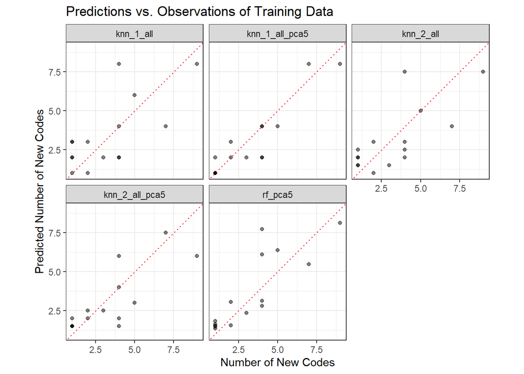

## Create and Evaluate our metrics to judge the models

```r
metrics <- metric_set(rmse,
                      rsq_trad,
                      mae)
```

Evaluation Metrics

| work_names | .metric | .estimator | .estimate |
| --- | --- | --- | --- |
| knn_1_all | rmse | standard | 1.789 |
| knn_1_all_pca5 | rmse | standard | 0.966 |
| knn_2_all | rmse | standard | 1.628 |
| knn_2_all_pca5 | rmse | standard | 1.414 |
| rf_pca5 | rmse | standard | 1.391 |
| knn_1_all | rsq_trad | standard | 0.407 |
| knn_1_all_pca5 | rsq_trad | standard | 0.827 |
| knn_2_all | rsq_trad | standard | 0.509 |
| knn_2_all_pca5 | rsq_trad | standard | 0.629 |
| rf_pca5 | rsq_trad | standard | 0.641 |
| knn_1_all | mae | standard | 1.467 |
| knn_1_all_pca5 | mae | standard | 0.667 |
| knn_2_all | mae | standard | 1.367 |
| knn_2_all_pca5 | mae | standard | 1.067 |
| rf_pca5 | mae | standard | 1.111 |

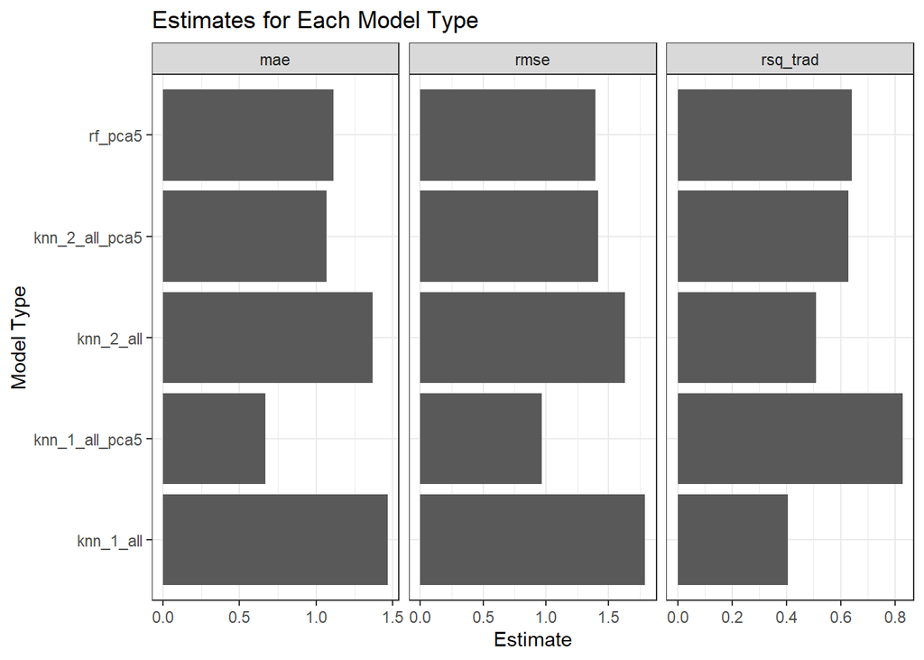

Currently, it looks like the k-nearest neighbors model originally choosing all predictors available but picking the best 5 principal components is showing the best performance on the test data at about .827 as closer to 1 is best. Additionally, the lower MAE and RMSE suggest a better fitting model. Here we see the lowest for k-nearest neighbors with 5 principal components as well.

## Validation Testing

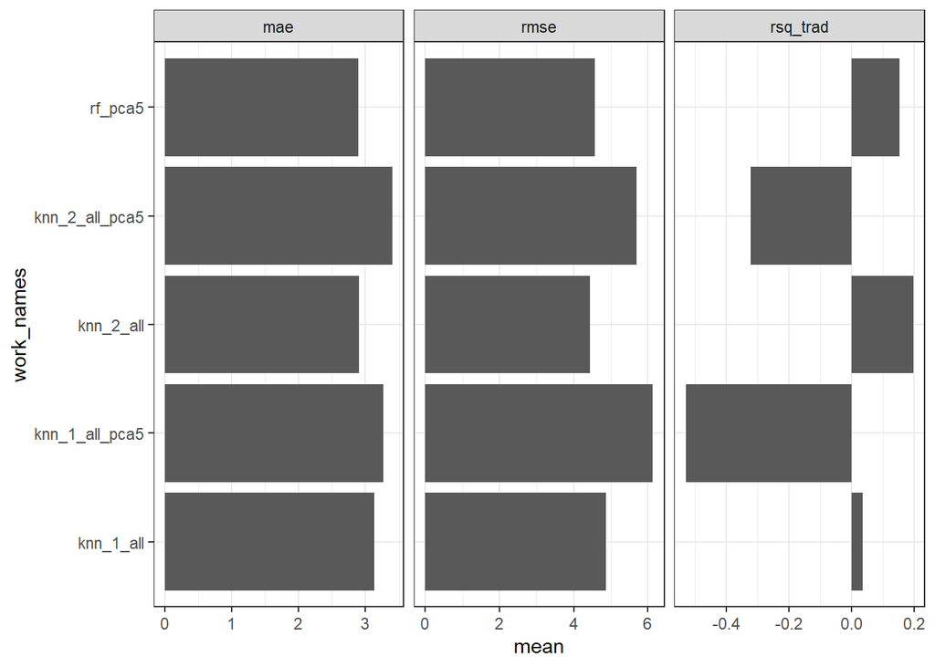

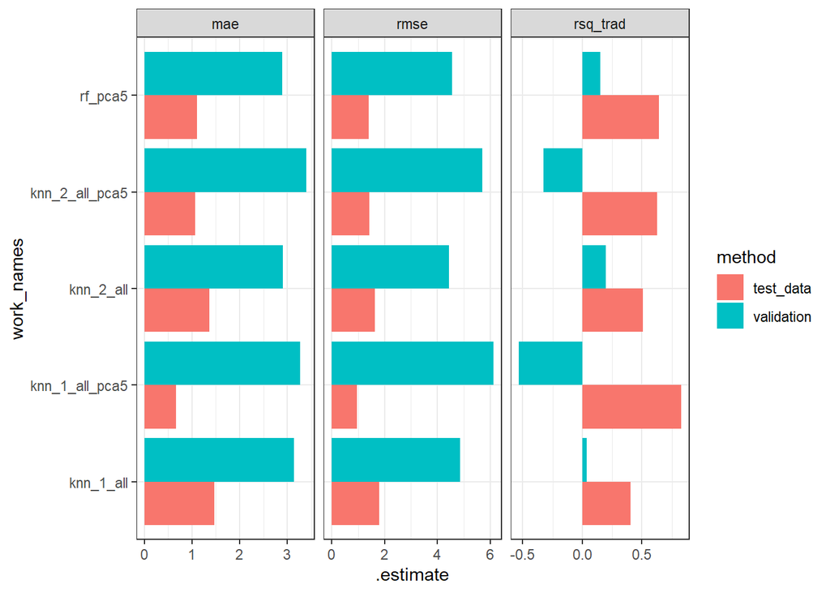

## V-Fold Cross Validation

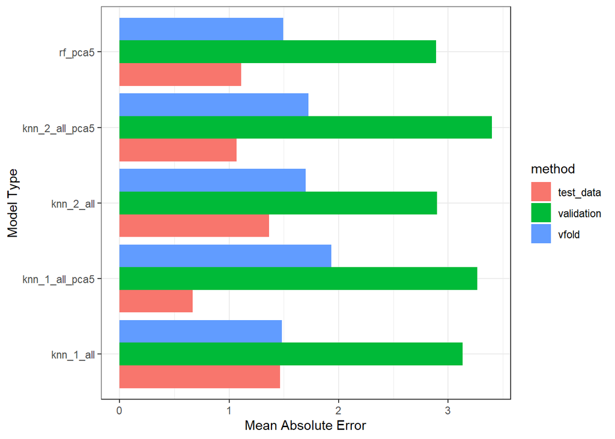

V-Fold Performance Metrics by Model

| work_names | method | mae | rmse | rsq_trad |
| --- | --- | --- | --- | --- |
| knn_1_all | vfold | 1.48 | 2.05 | -0.85 |
| knn_2_all | vfold | 1.70 | 2.38 | -0.94 |
| knn_1_all_pca5 | vfold | 1.93 | 2.66 | -1.38 |
| knn_2_all_pca5 | vfold | 1.72 | 2.39 | -0.53 |
| rf_pca5 | vfold | 1.50 | 2.04 | -0.84 |

# COMPONENT 6

Organize and present your results as a polished report in a Quarto HTML file. The document should be clearly communicated: section headings, brief descriptions of your analyses, and comments on the figures and results. Do not feel like you need to write at length, but it is worth practicing writing up your conclusions clearly and concisely, along with accompanying figures, without relying on presenting raw code.

To maximize readability and presentation, use chunk modifiers such as `#| echo:FALSE`, `#| message: FALSE`, and `#| warning: FALSE` to avoid showing parts of your R code that are not related to the direct results.

In addition to your polished report, I’d like the opportunity to review your code, so please submit the `.qmd` file alongside your report. If you choose to conduct some of your pre-analysis and assembling of the data in a separate `.R` or `.qmd` file, please include that in your submission as well.

These 15 points associated with this section will be awarded based on the quality of how the results are presented in the report.

This document serves as the output to satisfy Component 6.